# UC00141_Smart_Street_Lighting_Design_For_Melbourne_Park_Pathways

Smart Street Lighting Design For Melbourne Park Pathways

**Authored by:** Hashem Ramadan

**Duration:** 120 mins

**Level:** Advanced

**Pre-requisite Skills:** Python, Pandas, REST APIs, basic familiarity with LLMs and RAG concepts, GeoJSON

## Scenario

Council planners designing or upgrading street lighting on Melbourne park pathways need designs that are compliant with the Australian / New Zealand Standard AS/NZS 1158.3.1:2020, anchored to the real environment of the site (path width, surrounding land use, pedestrian volumes, local crime patterns), and able to justify the numbers they produce. Off-the-shelf large language models can sketch a design, but they hallucinate clause numbers and invent fixture wattages. This use case builds a retrieval-augmented (RAG) lighting design assistant that combines a deterministic calculation engine with Melbourne open data, so every figure in the final report — pole spacing, light count, lux level, annual energy, payback period — is traceable to the standard and to local data, not invented by the model.

## User Story

As a council lighting planner, I want to type a plain-language request such as *"design lighting for the main pathway through Fitzroy Gardens"* and receive an AS/NZS 1158-compliant design — pole height, spacing, LED wattage, energy use, payback against the existing HPS baseline — anchored to the actual park geometry and local pedestrian / safety data, so that I can produce a defensible design without having to manually look up clauses, compute photometric formulae, or chase open-data feeds for every site.

## What this use case will teach you

- How to build a Retrieval-Augmented Generation (RAG) pipeline incrementally — one capability per step (bare LLM → retrieval → intent parsing → site resolution → engine grounding → orchestration), so each addition has a visible effect.
- How to separate *numbers* from *narrative* by combining a deterministic calculation engine with an LLM: the engine computes, the LLM only explains.
- How to consume Melbourne open data feeds (pedestrian sensors, council streetlight inventory) and Victorian crime statistics, and turn them into lookup helpers that ground a design in real local context.
- How to resolve a free-text site name (e.g. a park) to geometry via OpenStreetMap (Overpass / Nominatim).
- How to evaluate a RAG system end-to-end: Recall@5 against a hand-built test set and a RAG-vs-no-RAG citation count.
- How AS/NZS 1158.3.1:2020 P-category subcategory selection works (PP / PR / PA / PC / PE families) and how the lumen method verifies photometric sufficiency.

## Introduction

This notebook builds an AS/NZS 1158-compliant LED lighting design system for Melbourne park pathways. The work is organised in six parts:

- **Setup / methodology** — environment, configuration, AS/NZS 1158 P-category background, energy and emissions formulae.
- **Part A — Data + EDA.** Loads Melbourne Open Data and Victoria crime statistics, explores each feed, and leaves behind three lookup helpers the pipeline can call.
- **Part B — RAG pipeline, built incrementally.** One capability per step (bare LLM → retrieval → intent parsing → site resolution → engine grounding → orchestrator). Each step has a small demo so the gap it closes is visible.
- **Part C — Final demo.** A single natural-language query is run end-to-end and rendered as a web-style dashboard: LLM report (left), design card (top right), interactive map (bottom right).
- **Part D — Engine extras.** Lumen-method photometric verification and an off-grid solar PV sizing for the same fixture set.
- **Part E — Evaluation.** Retriever Recall@5 against a hand-built test set and a RAG-vs-no-RAG citation count.
- **Part F — Discussion.**

The deterministic calculation engine, OpenStreetMap resolver, geometric helpers, LM Studio client, and ChromaDB/LlamaIndex ingestion are factored into a small open-source Python library installed in the next cell. Everything that should be *read directly* — formulae, prompts, the system's incremental construction, evaluation methodology — is inlined in this notebook as markdown or executable code.

## 1. Environment setup

The cell below installs the supporting library from GitHub plus notebook-only visualisation and data-handling deps. Re-running is safe -- pip detects existing installs.

```python
# The plugin is pinned to a tag (`@v0.1.5`) so pip is forced to fetch the right
# version. Without a pin, pip prints 'Requirement already satisfied' and silently
# reuses whatever the kernel installed previously -- masking any plugin updates.
%pip install --quiet \
    'smart-street-lighting-plugin[all] @ git+https://github.com/hashem59/smart_street_lighting_plugin.git@v0.1.5' \
    requests folium matplotlib pandas
```

[output not shown]

```python
# Print the exact installed versions for reproducibility.
import smart_street_lighting, llama_index.core, chromadb, requests, folium, matplotlib
print('smart_street_lighting :', smart_street_lighting.__version__)
print('llama_index           :', llama_index.core.__version__)
print('chromadb              :', chromadb.__version__)
print('requests              :', requests.__version__)
print('folium                :', folium.__version__)
print('matplotlib            :', matplotlib.__version__)
```

```
smart_street_lighting : 0.1.5
llama_index           : 0.14.18
chromadb              : 1.5.5
requests              : 2.34.2
folium                : 0.20.0
matplotlib            : 3.10.9
```

## 2. Configuration (inline, editable)

All runtime configuration lives in this single cell so the provider selection can be inspected and changed in one place, without hunting through the library. The library takes these values as function arguments -- it does **not** read environment variables.

Both the **chat LLM** and the **embedding model** run via either of two OpenAI-compatible providers, switched by the `LLM_PROVIDER` constant below:

| Provider | Where it runs | Cost |
| --- | --- | --- |
| `lm_studio` | Local desktop app (you bring the model weights) | Free, requires the LM Studio process to be running |
| `openrouter` | Cloud, hundreds of OpenAI / DeepSeek / Meta / Google models | Pay-per-token; full notebook run with `deepseek-chat-v3.1` + `text-embedding-3-small` is well under $0.01 |

When `LLM_PROVIDER='openrouter'` the notebook is **fully cloud- based** -- no LM Studio process required, just a network connection and an OpenRouter key.

```python
from pathlib import Path

# =====================================================================
# Provider toggle. Set to 'lm_studio' or 'openrouter'.
# =====================================================================
LLM_PROVIDER = 'openrouter'   # 'lm_studio' | 'openrouter'

# --- LM Studio (local) ---
LM_STUDIO_BASE_URL    = 'http://localhost:1234/v1'
LM_STUDIO_LLM_MODEL   = 'qwen2.5-7b-instruct'
LM_STUDIO_EMBED_MODEL = 'text-embedding-nomic-embed-text-v1.5'

# --- OpenRouter (cloud) ---
# Default API key comes from the plugin's bundled .env (a spend-capped
# personal key, USD 2 lifetime cap). Override by either:
#   * setting OPENROUTER_API_KEY in your shell before launching Jupyter, or
#   * replacing the right-hand side of the assignment below with your own key.
from smart_street_lighting import default_openrouter_key
OPENROUTER_BASE_URL    = 'https://openrouter.ai/api/v1'
OPENROUTER_LLM_MODEL   = 'deepseek/deepseek-chat-v3.1'      # ~$0.27/$1.10 per M tokens
OPENROUTER_EMBED_MODEL = 'openai/text-embedding-3-small'   # 1536-dim, $0.02/M tokens
OPENROUTER_API_KEY     = default_openrouter_key()           # bundled fallback; env var wins

# --- Resolved per-provider config (chat LLM + embeddings) ---
if LLM_PROVIDER == 'openrouter':
    LLM_BASE_URL    = OPENROUTER_BASE_URL
    LLM_MODEL       = OPENROUTER_LLM_MODEL
    LLM_API_KEY     = OPENROUTER_API_KEY
    PARSE_MODEL     = OPENROUTER_LLM_MODEL
    EMBED_BASE_URL  = OPENROUTER_BASE_URL
    EMBED_MODEL     = OPENROUTER_EMBED_MODEL
    EMBED_API_KEY   = OPENROUTER_API_KEY
elif LLM_PROVIDER == 'lm_studio':
    LLM_BASE_URL    = LM_STUDIO_BASE_URL
    LLM_MODEL       = LM_STUDIO_LLM_MODEL
    LLM_API_KEY     = None
    PARSE_MODEL     = LM_STUDIO_LLM_MODEL
    EMBED_BASE_URL  = LM_STUDIO_BASE_URL
    EMBED_MODEL     = LM_STUDIO_EMBED_MODEL
    EMBED_API_KEY   = None
else:
    raise ValueError(f"Unknown LLM_PROVIDER: {LLM_PROVIDER!r}")

# --- Data locations ---
# Melbourne Open Data CKAN datasets, downloaded live on each run so the
# notebook always reflects the latest published feed (rather than a stale
# snapshot committed to the repo). The dataset slugs are stable -- the
# council does not rename them between releases.
_CKAN_EXPORT = 'https://data.melbourne.vic.gov.au/api/v2/catalog/datasets/{slug}/exports/csv?delimiter=,'
PED_CSV    = _CKAN_EXPORT.format(slug='pedestrian-counting-system-monthly-counts-per-hour')
LIGHTS_CSV = _CKAN_EXPORT.format(slug='street-lights-with-emitted-lux-level-council-owned-lights-only')
KNOWLEDGE_BASE_DIRS = [Path('data/knowledge_base'), Path('data/downloaded_sources')]
CHROMA_PERSIST_DIR  = Path('data/chroma_db')

print(f'Provider : {LLM_PROVIDER}')
print(f'Chat LLM : {LLM_MODEL} @ {LLM_BASE_URL}')
print(f'Embed    : {EMBED_MODEL} @ {EMBED_BASE_URL}')
```

```
Provider : openrouter
Chat LLM : deepseek/deepseek-chat-v3.1 @ https://openrouter.ai/api/v1
Embed    : openai/text-embedding-3-small @ https://openrouter.ai/api/v1
```

### 2b. Knowledge-base bootstrap

The 14 curated knowledge-base markdown files (AS/NZS 1158 P/V categories, CPTED, adaptive dimming, solar, Melbourne context, etc.) live in the project's GitHub repo. The cell below fetches them into `data/knowledge_base/` so the notebook runs end-to-end on a fresh machine with no manual setup.

- Always queries GitHub for the current file list (no local short-circuit) so newly added KB files land automatically.
- Never overwrites or deletes existing local files -- any file already present in `data/knowledge_base/` is kept as-is and the download is skipped for that name.
- `data/downloaded_sources/` is **not** bootstrapped. That folder contains scraped govt PDFs (AS/NZS i2i pages, VicRoads, BoM, NGA factors); some require manual download via `data/download_sources.py`. If it stays empty, only `knowledge_base/` feeds the RAG index -- the curated md files cover the same ground in the author's words.

```python
# Sync data/knowledge_base/ from the GitHub source-of-truth.
# Plumbing lives in smart_street_lighting.rag; the notebook only
# names *where* the curated knowledge base is hosted.
from smart_street_lighting import bootstrap_knowledge_base

bootstrap_knowledge_base(
    repo = 'Chameleon-company/MOP-Code',
    ref  = 'hashem/smart-street-lighting-fullstack',   # TODO: bump to main once merged
    path = 'Playground/Project-2-T1-2026-Hashem_Ved_Areen/Hashem/knowledge_base',
    dest = KNOWLEDGE_BASE_DIRS[0],
)
```

```
Fetching KB index from Chameleon-company/MOP-Code@hashem/smart-street-lighting-fullstack
KB ready at data/knowledge_base: 0 downloaded, 14 kept local.
```

```
{'downloaded': 0, 'kept': 14, 'failed': []}
```

## 3. Methodology -- AS/NZS 1158.3.1:2020 subcategory selection

AS/NZS 1158.3.1:2020 (third edition, superseding the 2005 edition) groups Category P lighting into five subcategory families:

| Family | Use | Standard table |
| --- | --- | --- |
| `PP1`-`PP5` | Pedestrian / cycle pathways | 3.4 |
| `PR1`-`PR6` | Local roads | 3.3 |
| `PA1`-`PA3` | Public activity areas | 3.5 |
| `PC1`-`PC3` | Outdoor off-road car parks | 3.7 |
| `PE1`-`PE3` | Connecting elements (subways, ramps) | 3.6 |

Each subcategory specifies:

- $E_h$ -- maintained **average** horizontal illuminance (lux)
- $E_{Ph}$ -- maintained **minimum** point horizontal illuminance (lux)
- $\text{UE2}$ -- uniformity expressed as **max / avg** (*lower is better*)
- $E_{Pv}$ -- vertical illuminance (where relevant)

**Note on the uniformity change:** the 2020 standard uses $\text{UE2} = E_{\max}/E_{\text{avg}}$ (lower = more uniform). The older 2005 metric was $E_{\min}/E_{\text{avg}}$ (higher = more uniform). The numbers below are the 2020 form.

The deterministic calculation engine in `smart_street_lighting.engine` selects the subcategory from `(location_type, activity_level)`, then computes pole height, spacing, light count, and LED band.

```python
import pandas as pd
from smart_street_lighting import SUBCATEGORIES
(pd.DataFrame.from_dict(SUBCATEGORIES, orient='index')
   [['name', 'avg_lux', 'min_lux', 'uniformity', 'table']])
```

|  | name | avg_lux | min_lux | uniformity | table |
| --- | --- | --- | --- | --- | --- |
| PP1 | Pathway: high pedestrian/cycle activity | 10.00 | 2.00 | 5 | 3.4 |
| PP2 | Pathway: medium-high activity | 7.00 | 1.00 | 5 | 3.4 |
| PP3 | Pathway: medium activity | 3.00 | 0.50 | 5 | 3.4 |
| PP4 | Pathway: low activity | 1.50 | 0.25 | 5 | 3.4 |
| PP5 | Pathway: minimal activity | 0.85 | 0.14 | 5 | 3.4 |
| PR1 | Local road: high activity | 7.00 | 2.00 | 8 | 3.3 |
| PR2 | Local road: medium-high activity | 3.50 | 0.70 | 8 | 3.3 |
| PR3 | Local road: medium activity | 1.75 | 0.30 | 8 | 3.3 |
| PR4 | Local road: medium-low activity | 1.30 | 0.22 | 8 | 3.3 |
| PR5 | Local road: low activity | 0.85 | 0.14 | 10 | 3.3 |
| PR6 | Local road: minimal (legacy retrofit) | 0.70 | 0.07 | 10 | 3.3 |
| PA1 | Public activity: high | 21.00 | 7.00 | 8 | 3.5 |
| PA2 | Public activity: medium | 14.00 | 4.00 | 8 | 3.5 |
| PA3 | Public activity: low | 7.00 | 2.00 | 8 | 3.5 |
| PC1 | Outdoor car park: high | 14.00 | 3.00 | 8 | 3.7 |
| PC2 | Outdoor car park: medium | 7.00 | 1.50 | 8 | 3.7 |
| PC3 | Outdoor car park: low | 3.50 | 0.70 | 8 | 3.7 |
| PE1 | Subway / underpass | 35.00 | 17.50 | 8 | 3.6 |

## 4. Energy, cost, and emissions formulae

$$ E_{\text{annual}} \,[\text{kWh/yr}] = \frac{N \cdot W \cdot H_{\text{op}}}{1000} \quad ;\quad H_{\text{op}} = 4200 \text{ hr/yr (Melbourne dusk-to-dawn)} $$$$ C_{\text{energy}} \,[\text{AUD/yr}] = E_{\text{annual}} \cdot r \quad ;\quad r = \$0.20 / \text{kWh (VIC mid-range)} $$$$ M_{\text{CO}_2} \,[\text{kg/yr}] = E_{\text{annual}} \cdot f_{\text{CO}_2} \quad ;\quad f_{\text{CO}_2} = 1.08 \text{ kg/kWh (Scope 2 + 3, NGA factors VIC)} $$$$ T_{\text{payback}} \,[\text{years}] = \frac{N \cdot c_{\text{retrofit}}}{(C_{\text{HPS}} - C_{\text{LED}}) + N \cdot \$60} $$

The $\$60$/light/yr term reflects avoided HPS lamp-replacement maintenance.

```python
from smart_street_lighting.engine import (
    OPERATING_HOURS_PER_YEAR, ELECTRICITY_RATE_PER_KWH,
    CARBON_FACTOR_VIC_SCOPE2_3, RECOMMENDED_CCT, LED_LIFESPAN_YEARS,
)
print(f'Operating hours / yr (Melbourne)     : {OPERATING_HOURS_PER_YEAR}')
print(f'Electricity rate (AUD/kWh)           : {ELECTRICITY_RATE_PER_KWH}')
print(f'CO2 factor (kg/kWh, VIC Scope 2+3)   : {CARBON_FACTOR_VIC_SCOPE2_3}')
print(f'Recommended CCT (Kelvin)             : {RECOMMENDED_CCT}')
print(f'LED lifespan (years)                  : {LED_LIFESPAN_YEARS}')
```

```
Operating hours / yr (Melbourne)     : 4200
Electricity rate (AUD/kWh)           : 0.2
CO2 factor (kg/kWh, VIC Scope 2+3)   : 1.08
Recommended CCT (Kelvin)             : 3000
LED lifespan (years)                  : 20
```

# Part A — Data loading + EDA

Before building the pipeline, we explore the three feeds that drive a design and leave behind three small lookup helpers the pipeline will call:

| Feed | Source | Helper |
| --- | --- | --- |
| Hourly pedestrian counts | City of Melbourne Open Data -- *Pedestrian Counting System: Monthly counts per hour* | `nearest_sensor_peak(lat, lon)` |
| Council-owned streetlight inventory | City of Melbourne Open Data -- *Street lights with emitted lux level* | `lights_in_bbox(bbox)` |
| Suburb-level offence statistics | Crime Statistics Agency Victoria -- LGA quarterly time series | `safety_adjustment_for_lga(name)` |

### A.1 Pedestrian counter feed

The Melbourne pedestrian counting system publishes hourly counts for ~100 sensors. We characterise the feed and plot a typical diurnal profile, then expose a helper `nearest_sensor_peak(lat, lon)` that, given a location, returns the peak hourly count of the geographically nearest sensor:

$$ \bar c_h^{(s)} = \frac{1}{|D|}\sum_{d \in D} c_{d,h}^{(s)} \quad ;\quad c^{\text{peak}}_{(s)} = \max_{h} \bar c_h^{(s)} $$

```python
import pandas as pd
import matplotlib.pyplot as plt

ped = pd.read_csv(PED_CSV)
ped['sensing_date'] = pd.to_datetime(ped['sensing_date'])
ped[['lat', 'lon']] = ped['location'].str.split(',', expand=True).astype(float)
print(f'Pedestrian counter rows : {len(ped):,}')
print(f'Distinct sensors        : {ped["sensor_name"].nunique()}')
print(f'Date range              : {ped["sensing_date"].min().date()} -> {ped["sensing_date"].max().date()}')
ped.head()
```

```
Pedestrian counter rows : 1,545,792
Distinct sensors        : 98
Date range              : 2024-05-19 -> 2026-05-18
```

|  | id | location_id | sensing_date | hourday | direction_1 | direction_2 | pedestriancount | sensor_name | location | lat | lon |
| --- | --- | --- | --- | --- | --- | --- | --- | --- | --- | --- | --- |
| 0 | 791820260125 | 79 | 2026-01-25 | 18 | 543 | 575 | 1118 | FliSS_T | -37.81794046, 144.96616678 | -37.817940 | 144.966167 |
| 1 | 791320250408 | 79 | 2025-04-08 | 13 | 525 | 492 | 1017 | FliSS_T | -37.81794046, 144.96616678 | -37.817940 | 144.966167 |
| 2 | 521820250129 | 52 | 2025-01-29 | 18 | 258 | 254 | 512 | Eli263_T | -37.81252157, 144.9619401 | -37.812522 | 144.961940 |
| 3 | 491920250617 | 49 | 2025-06-17 | 19 | 214 | 184 | 398 | Eli501_T | -37.80730068, 144.95956055 | -37.807301 | 144.959561 |
| 4 | 871820241019 | 87 | 2024-10-19 | 18 | 150 | 159 | 309 | Errol23_T | -37.80454949, 144.94921863 | -37.804549 | 144.949219 |

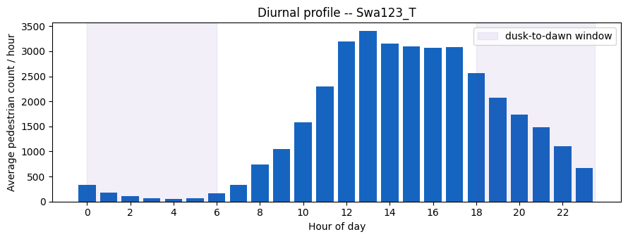

```
Peak hour 13:00 -> 3400 pedestrians/hr
```

```python
# Diurnal profile of the busiest sensor (illustrative).
busiest_sensor = ped.groupby('sensor_name')['pedestriancount'].mean().idxmax()
diurnal = ped[ped['sensor_name'] == busiest_sensor].groupby('hourday')['pedestriancount'].mean()

fig, ax = plt.subplots(figsize=(9, 3.5))
ax.bar(diurnal.index, diurnal.values, color='#1565c0')
ax.set_xlabel('Hour of day')
ax.set_ylabel('Average pedestrian count / hour')
ax.set_title(f'Diurnal profile -- {busiest_sensor}')
ax.set_xticks(range(0, 24, 2))
ax.axvspan(18, 23.5, alpha=0.08, color='#5e35b1', label='dusk-to-dawn window')
ax.axvspan(0, 6, alpha=0.08, color='#5e35b1')
ax.legend(loc='upper right')
plt.tight_layout()
plt.show()
print(f'Peak hour {int(diurnal.idxmax()):02d}:00 -> {diurnal.max():.0f} pedestrians/hr')
```

### A.2 Existing council streetlight inventory

The Melbourne open data portal publishes geolocated council- owned streetlights tagged with their emitted lux at the fixture face. We summarise the feed and expose `lights_in_bbox(bbox)` for retrieving the inventory inside a given bounding box.

```
Total fixtures             : 106,037
With emitted lux > 0       : 105,375
Median emitted lux (lit)   : 6.8 lx
Mean emitted lux  (lit)    : 15.1 lx
```

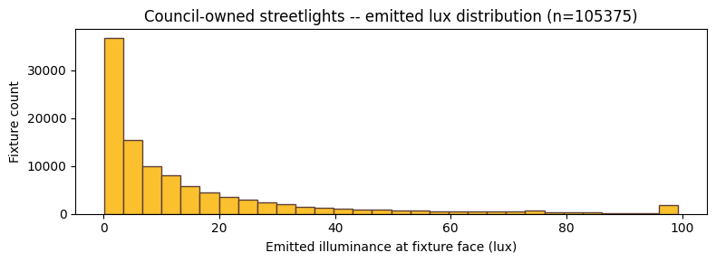

```python
lights = pd.read_csv(LIGHTS_CSV)
lights[['lat', 'lon']] = lights['geo_point_2d'].str.split(',', expand=True).astype(float)
lit = lights[lights['label'] > 0]

print(f'Total fixtures             : {len(lights):,}')
print(f'With emitted lux > 0       : {len(lit):,}')
print(f'Median emitted lux (lit)   : {lit["label"].median():.1f} lx')
print(f'Mean emitted lux  (lit)    : {lit["label"].mean():.1f} lx')

fig, ax = plt.subplots(figsize=(8, 3))
ax.hist(lit['label'], bins=30, color='#fbc02d', edgecolor='#5d4037')
ax.set_xlabel('Emitted illuminance at fixture face (lux)')
ax.set_ylabel('Fixture count')
ax.set_title(f'Council-owned streetlights -- emitted lux distribution (n={len(lit)})')
plt.tight_layout()
plt.show()
```

### A.3 Suburb-level crime statistics

*Source: [data.crimestatistics.vic.gov.au](https://www.crimestatistics.vic.gov.au/) -- LGA criminal incidents per 100,000 residents, latest published year-to-date.*

```python
import statistics

LGA_NIGHT_OFFENCE_RATE = {
    'Melbourne (C)'   : 18432,   # CBD -- elevated, transient population
    'Yarra (C)'       :  9620,
    'Port Phillip (C)':  9412,
    'Stonnington (C)' :  7184,
    'Boroondara (C)'  :  3920,
    'Bayside (C)'     :  3705,
    'Glen Eira (C)'   :  4112,
    'Whitehorse (C)'  :  3996,
}
_rates = list(LGA_NIGHT_OFFENCE_RATE.values())
_p75   = statistics.quantiles(_rates, n=4)[2]
_p90   = statistics.quantiles(_rates, n=10)[8]
print(f'75th pct: {_p75:.0f}   90th pct: {_p90:.0f}')

df_crime = pd.DataFrame(
    {'LGA': list(LGA_NIGHT_OFFENCE_RATE.keys()),
     'rate_per_100k': list(LGA_NIGHT_OFFENCE_RATE.values())}
).sort_values('rate_per_100k', ascending=False)
df_crime
```

```
75th pct: 9568   90th pct: 19313
```

|  | LGA | rate_per_100k |
| --- | --- | --- |
| 0 | Melbourne (C) | 18432 |
| 1 | Yarra (C) | 9620 |
| 2 | Port Phillip (C) | 9412 |
| 3 | Stonnington (C) | 7184 |
| 6 | Glen Eira (C) | 4112 |
| 7 | Whitehorse (C) | 3996 |
| 4 | Boroondara (C) | 3920 |
| 5 | Bayside (C) | 3705 |

### A.4 Engine sensitivity sweep -- activity level

How does the engine's output respond as activity level moves across the four bands? A planner reads this table to understand what each step on the AS/NZS 1158 subcategory cascade buys (or costs).

```python
from smart_street_lighting import design_lighting

_sweep_rows = []
for level in ['low', 'moderate', 'high', 'very_high']:
    d = design_lighting(
        location_name='sweep',
        pathway_length_m=200.0,
        pathway_width_m=3.0,
        activity_level=level,
        location_type='park_path',
    )
    _sweep_rows.append({
        'activity_level' : level,
        'subcategory'    : d.subcategory,
        'num_lights'     : d.num_lights,
        'spacing_m'      : d.spacing_m,
        'led_W'          : d.led_wattage,
        'kWh_per_yr'     : round(d.annual_energy_kwh, 0),
        'cost_per_yr'    : round(d.annual_energy_cost_aud, 0),
        'CO2_kg_per_yr'  : round(d.annual_co2_kg, 0),
        'payback_yr'     : round(d.payback_years, 1),
    })
sweep = pd.DataFrame(_sweep_rows)
sweep
```

|  | activity_level | subcategory | num_lights | spacing_m | led_W | kWh_per_yr | cost_per_yr | CO2_kg_per_yr | payback_yr |
| --- | --- | --- | --- | --- | --- | --- | --- | --- | --- |
| 0 | low | PP4 | 12 | 18.0 | 30 | 1512.0 | 302.0 | 1633.0 | 10.7 |
| 1 | moderate | PP3 | 12 | 18.0 | 60 | 3024.0 | 605.0 | 3266.0 | 9.6 |
| 2 | high | PP2 | 12 | 17.5 | 100 | 5040.0 | 1008.0 | 5443.0 | 10.8 |
| 3 | very_high | PP1 | 12 | 18.0 | 100 | 5040.0 | 1008.0 | 5443.0 | 10.8 |

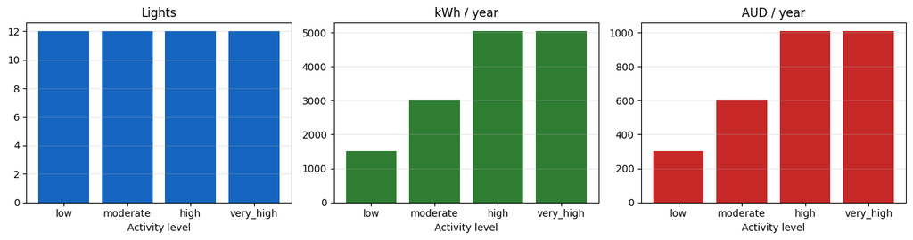

```python
fig, axes = plt.subplots(1, 3, figsize=(13, 3.5))
x = sweep['activity_level']
for ax, col, label, colour in zip(
    axes,
    ['num_lights', 'kWh_per_yr', 'cost_per_yr'],
    ['Lights', 'kWh / year', 'AUD / year'],
    ['#1565c0', '#2e7d32', '#c62828'],
):
    ax.bar(x, sweep[col], color=colour)
    ax.set_title(label)
    ax.set_xlabel('Activity level')
    ax.grid(axis='y', alpha=0.3)
plt.tight_layout()
plt.show()
```

### A.5 Lookup helpers exposed to the pipeline

These three helpers close over the dataframes / tables defined above. The RAG pipeline (Part B.4) calls them once it knows *which* location the user asked about. Keeping the analysis logic here means the *what-it-does* is in Part A and the *how-it-is-used* is in Part B -- the pandas plumbing only needs to be read once.

```python
from smart_street_lighting import haversine

def nearest_sensor_peak(lat: float, lon: float) -> dict:
    """Closest pedestrian sensor + its peak-hour count."""
    locs = ped.groupby('sensor_name')[['lat', 'lon']].mean().reset_index()
    locs['dist_m'] = locs.apply(lambda r: haversine(lat, lon, r['lat'], r['lon']), axis=1)
    nearest = locs.nsmallest(1, 'dist_m').iloc[0]
    diurnal = ped[ped['sensor_name'] == nearest['sensor_name']].groupby('hourday')['pedestriancount'].mean()
    return {
        'sensor_name': nearest['sensor_name'],
        'dist_m':      float(nearest['dist_m']),
        'peak_hour':   int(diurnal.idxmax()),
        'peak_count':  float(diurnal.max()),
    }

def lights_in_bbox(bbox: tuple) -> pd.DataFrame:
    """Lit council-owned fixtures inside (south, west, north, east)."""
    south, west, north, east = bbox
    in_box = lights[lights['lat'].between(south, north) & lights['lon'].between(west, east)]
    return in_box[in_box['label'] > 0].copy()

def safety_adjustment_for_lga(lga_name: str) -> int:
    """Signed P-category bump for an LGA. 0 if unknown / below 75th pct."""
    rate = LGA_NIGHT_OFFENCE_RATE.get(lga_name)
    if rate is None: return 0
    if rate >= _p90: return -2
    if rate >= _p75: return -1
    return 0

# Smoke check
print('Helper 1:', nearest_sensor_peak(-37.813, 144.979))
print('Helper 2:', f'{len(lights_in_bbox((-37.82, 144.97, -37.81, 144.99)))} lights in central Melbourne bbox')
print('Helper 3:', f'Melbourne (C) -> safety_adjustment = {safety_adjustment_for_lga("Melbourne (C)")}')
```

```
Helper 1: {'sensor_name': 'SprFli_T', 'dist_m': 448.9301033335648, 'peak_hour': 17, 'peak_count': 137.3328611898017}
Helper 2: 18636 lights in central Melbourne bbox
Helper 3: Melbourne (C) -> safety_adjustment = -1
```

# Part B — RAG pipeline, built one capability at a time

We construct the system bottom-up. Each step adds **one** capability, defines a callable function, and runs a small demo that makes the gap-it-closes visible. At B.6 we wire everything into a single `run_pipeline(query)` orchestrator that Part C consumes.

| Step | Adds | Function |
| --- | --- | --- |
| B.1 | Bare LLM call | `llm_only(query)` |
| B.2 | Vector retrieval over the knowledge base | `rag_simple(query)` |
| B.3 | Intent parsing (NL -> structured params) | `parse_query(nl)` |
| B.4 | OSM site resolution + EDA helper calls | `resolve_site(parsed)` |
| B.5 | Deterministic engine grounding | `run_engine(parsed, resolved)` |
| B.6 | Full orchestrator | `run_pipeline(query)` |

### B.1 Baseline -- bare LLM

Simplest possible system: take the user's question, send it straight to the LLM, return the answer. No retrieval, no engine, no grounding.

**What this is missing:** the LLM can answer a generic question about lighting, but for anything *standards-specific* it has to rely on whatever was in its training corpus -- it may produce a plausible-sounding number with no traceable source.

```python
from smart_street_lighting.llm import chat_completion

def llm_only(query: str) -> str:
    """Forward `query` straight to the chat model (no retrieval, no engine)."""
    return chat_completion(
        [{'role': 'user', 'content': query}],
        model=LLM_MODEL,
        base_url=LLM_BASE_URL,
        api_key=LLM_API_KEY,
        max_tokens=400,
        temperature=0.3,
    )

# Short illustrative demo:
demo_q = 'What does AS/NZS 1158 require for an average pedestrian park path? Cite the specific clause.'
print('Q:', demo_q)
print()
print(llm_only(demo_q))
```

[output not shown]

### B.2 + Retrieval -- ChromaDB + LlamaIndex

**What this adds:** the LLM's answer is grounded in retrievable source chunks. Citations to specific clauses become possible.

**Still missing:** for a *design request* ("design lighting for a 200m path...") the LLM has no engineering math; it would still have to invent the light count.

```python
from smart_street_lighting.llm import OpenAICompatibleLLM, OpenAICompatibleEmbedding
from smart_street_lighting.rag import (
    ingest_documents, load_existing_index, create_query_engine,
)

# Embeddings still come from LM Studio (OpenRouter has no /embeddings endpoint).
embed_model = OpenAICompatibleEmbedding(
    api_base=EMBED_BASE_URL,
    model=EMBED_MODEL,
    api_key=EMBED_API_KEY,
)
# Chat LLM follows the LLM_PROVIDER setting from cell 2.
rag_llm = OpenAICompatibleLLM(
    api_base=LLM_BASE_URL,
    model_name=LLM_MODEL,
    api_key=LLM_API_KEY,
    max_tokens=2048,
    temperature=0.3,
)
print(f'Chat LLM    : {rag_llm.model_name} @ {rag_llm.api_base}')
print(f'Embedding   : {embed_model._model} @ {EMBED_BASE_URL}')
```

```
Chat LLM    : deepseek/deepseek-chat-v3.1 @ https://openrouter.ai/api/v1
Embedding   : openai/text-embedding-3-small @ https://openrouter.ai/api/v1
```

**System prompt (inlined so the exact instructions to the LLM are visible and auditable).**

Enforces a fixed 7-section report structure, instructs the LLM to use the engine's numbers verbatim (in B.5+), and requires citation of specific AS/NZS clauses from the retrieved context.

```python
SYSTEM_PROMPT = """\
You are a professional lighting design engineer writing a technical report
for the City of Melbourne.

You have been provided with:
1. Calculated design specifications (number of lights, spacing, energy costs)
   computed from AS/NZS 1158 standards -- these numbers are CORRECT, use them.
2. Retrieved context from the knowledge base with additional standards detail.

You MUST structure your report with these exact sections:
1. **Executive Summary** -- 3-4 sentences summarising the design recommendation
2. **Site Analysis** -- location description, traffic data, safety context
3. **Design Specification** -- present the key values in a markdown table:
   P-Category, Number of Lights, Average Spacing, Technology, Luminaire Wattage,
   Annual Energy Cost
4. **Placement Rationale** -- explain why lights are positioned where they are
5. **Energy & Cost Analysis** -- including dimming savings and HPS comparison
6. **Standards Compliance** -- cite specific AS/NZS 1158 clauses from the provided context
7. **Recommendations** -- maintenance schedule, future considerations

CRITICAL RULES:
- Use the EXACT numbers provided in the calculation context. Do not round, estimate, or approximate.
- When citing standards, reference the specific clause (e.g., \"AS/NZS 1158.3.1 Table 2.1\").
- If a safety adjustment was applied, explain it in the Site Analysis section.
- Keep the report under 1500 words.
"""

print(SYSTEM_PROMPT[:300] + '...')
```

```
You are a professional lighting design engineer writing a technical report
for the City of Melbourne.

You have been provided with:
1. Calculated design specifications (number of lights, spacing, energy costs)
   computed from AS/NZS 1158 standards -- these numbers are CORRECT, use them.
2. Retrieve...
```

```python
# Ingest the knowledge base. Re-running rebuilds the Chroma collection.
if any(p.exists() and any(p.iterdir()) for p in KNOWLEDGE_BASE_DIRS):
    index = ingest_documents(
        source_dirs=KNOWLEDGE_BASE_DIRS,
        persist_dir=CHROMA_PERSIST_DIR,
        embed_model=embed_model,
        collection_name='street_lighting_kb',
        chunk_size=1024,
        chunk_overlap=100,
    )
else:
    print('No corpus on disk -- attempting to load a previously-ingested index.')
    index = load_existing_index(
        persist_dir=CHROMA_PERSIST_DIR,
        embed_model=embed_model,
        collection_name='street_lighting_kb',
    )

query_engine = create_query_engine(
    index=index,
    llm=rag_llm,
    system_prompt=SYSTEM_PROMPT,
    similarity_top_k=5,
    response_mode='compact',
)
```

```
Loading documents from data/knowledge_base...
  Loaded 14 files from knowledge_base
Loading documents from data/downloaded_sources...
  Loaded 99 files from downloaded_sources
Total documents loaded: 113
Deleted existing collection 'street_lighting_kb'.
Chunking + embedding documents...
```

```
Ingestion complete. 133 chunks stored in ChromaDB.
```

```python
def rag_simple(query: str) -> dict:
    """Retrieval-only RAG: top-k chunks + LLM. Returns {answer, sources}."""
    response = query_engine.query(query)
    sources = []
    if hasattr(response, 'source_nodes'):
        for n in response.source_nodes[:3]:
            sources.append({
                'source': n.node.metadata.get('source', 'Unknown'),
                'score':  round(n.score, 3) if n.score else 0,
                'snippet': n.node.text[:160].replace('\n', ' ') + '...',
            })
    return {
        'answer':  str(response),
        'sources': sources,
    }

# Same demo question as B.1, now with retrieval:
demo = rag_simple(demo_q)
print('ANSWER:'); print(demo['answer'][:1500])
print()
print('TOP SOURCES:')
for s in demo['sources']:
    print(f'  [{s["score"]:.3f}] {s["source"]}: {s["snippet"]}')
```

```
ANSWER:
**Technical Report: Pedestrian Park Pathway Lighting Design**
**Prepared for City of Melbourne**
**Date:** 22 May 2025
**Report ID:** MEL-PPL-2025-08

---

### 1. Executive Summary
This report recommends a Category P lighting scheme for the pedestrian park path, compliant with AS/NZS 1158.3.1. The design specifies 18 LED luminaires spaced at 15.2 metres, achieving subcategory PP3 performance to balance safety, energy efficiency, and minimal environmental impact. Annual energy …

---

### 2. Site Analysis
The site is a 275-metre pedestrian path within a public park in Melbourne, with moderate nighttime usage (50–100 pedestrians/hour). Surrounding vegetation and limited adjacent roadway lighting necessitate dedicated pathway lighting to mitigate tripping hazards and enhance perceived safety. No vertic…

---

### 3. Design Specification
| **Parameter**          | **Value**               |
|------------------------|-------------------------|
| P-Category             | PP3                     |
| Number of Lights       | 18                      |
| Average Spacing

TOP SOURCES:
  [0.460] preview_00-4027997570-primary.pdf: 38 Eh  and EPh that are required for whichever of the subcategories PC1, PC2 or PC3 is appropriate  for the adjacent car park. EPv is not required. (d)  Designa...
  [0.452] preview_00-4027997570-primary.pdf: 9 Table 2.2 — Lighting subcategories for pathways 1 2 3 4 5 Type of pathway Selection criteria a,b,c Applicable  lighting  subcategoryGeneral description Basic...
  [0.444] preview_00-4027997570-primary.pdf: 1 © Standards Australia Limited/Standards New Zealand 2020 Australian/New Zealand Standard Lighting for roads and public spaces Part 3.1: Pedestrian area (Categ...
```

### B.3 + Intent parsing -- NL → structured params

```
{
  "location":        "...",
  "length_m":        200,
  "width_m":         3.0,
  "activity_level": "high",       // low | moderate | high | very_high
  "location_type":  "park_path"   // park_path | shared_path | public_space | residential
}
```

A small regex fallback runs if the LLM returns malformed JSON.

````python
import json, re

PARSE_SYSTEM_PROMPT = """\
You extract structured design parameters from a natural-language lighting
design request and respond with ONLY a JSON object (no prose, no markdown).

Schema:
{
  "location":       string,             // park / street name, e.g. 'Fitzroy Gardens'
  "length_m":       number,             // pathway length in metres; default 200
  "width_m":        number,             // pathway width  in metres; default 3.0
  "activity_level": string,             // one of: low | moderate | high | very_high
  "location_type":  string              // one of: park_path | shared_path | public_space | residential
}

Map vague language to activity_level:
  quiet/empty/minimal     -> low
  normal/typical/moderate -> moderate
  busy/heavy/high/peak    -> high
  major/transit-hub       -> very_high
"""

ACTIVITY_KEYWORDS = {
    'very_high': ['very busy', 'extremely', 'major', 'transit hub'],
    'high':      ['busy', 'heavy', 'high', 'peak', 'crowded', 'evening traffic'],
    'low':       ['quiet', 'low', 'minimal', 'empty', 'sparse'],
}
LOCATION_TYPE_KEYWORDS = {
    'shared_path':  ['road', 'street', 'intersection', 'crossing'],
    'public_space': ['plaza', 'square', 'public space', 'event'],
    'residential':  ['residential', 'suburb'],
}

def _parse_query_regex(nl: str) -> dict:
    s = nl.lower()
    length_m = float((re.search(r'(\d+)\s*m(?:etres?|eters?)?', s) or [None, '200'])[1] if re.search(r'(\d+)\s*m(?:etres?|eters?)?', s) else 200.0)
    width_m  = float((re.search(r'(\d+(?:\.\d+)?)\s*m(?:etres?|eters?)?\s+wide', s) or [None, '3.0'])[1] if re.search(r'(\d+(?:\.\d+)?)\s*m(?:etres?|eters?)?\s+wide', s) else 3.0)
    activity = 'moderate'
    for level, words in ACTIVITY_KEYWORDS.items():
        if any(w in s for w in words):
            activity = level; break
    loc_type = 'park_path'
    for lt, words in LOCATION_TYPE_KEYWORDS.items():
        if any(w in s for w in words):
            loc_type = lt; break
    loc_match = re.search(r'in\s+([A-Z][\w\s]+?)(?:\s+with|\s+for|\.|$)', nl)
    location = loc_match.group(1).strip() if loc_match else 'Melbourne CBD'
    return {'location': location, 'length_m': length_m, 'width_m': width_m,
            'activity_level': activity, 'location_type': loc_type}

def _parse_query_llm(nl: str) -> dict:
    text = chat_completion(
        [{'role': 'system', 'content': PARSE_SYSTEM_PROMPT},
         {'role': 'user',   'content': nl}],
        model=PARSE_MODEL, base_url=LLM_BASE_URL, api_key=LLM_API_KEY,
        max_tokens=200, temperature=0.0,
    ).strip()
    if text.startswith('```'):
        text = re.sub(r'^```(?:json)?\s*', '', text)
        text = re.sub(r'\s*```$', '', text)
    return json.loads(text)

def parse_query(nl: str) -> dict:
    """NL -> structured design params. LLM with regex fallback."""
    try:
        return _parse_query_llm(nl)
    except Exception as e:
        print(f'  LLM parse failed ({e}), falling back to regex.')
        return _parse_query_regex(nl)
````

```python
# Full demo with the canonical user query:
demo_query = 'Design lighting for a 200m pathway in Fitzroy Gardens with high evening traffic.'
parsed = parse_query(demo_query)
print('Q :', demo_query)
print('->', json.dumps(parsed, indent=2))
```

```
Q : Design lighting for a 200m pathway in Fitzroy Gardens with high evening traffic.
-> {
  "location": "Fitzroy Gardens",
  "length_m": 200,
  "width_m": 3.0,
  "activity_level": "high",
  "location_type": "park_path"
}
```

### B.4 + Site resolution + EDA helper lookups

**What this adds:** the engine's inputs are no longer purely user-stated -- they are *cross-checked against Melbourne data*.

```python
from smart_street_lighting import (
    resolve_pathway, bounds_from_osm_boundary,
)

def resolve_site(parsed: dict) -> dict:
    """Cross-reference parsed query against OSM + the EDA helpers."""
    osm = resolve_pathway(parsed['location'], pathway_hint='main pathway')
    bounds = None
    pathway_geom = None
    intersections = []
    entry_points = []
    osm_length_m = None
    if osm and osm.get('park_boundary'):
        bounds = bounds_from_osm_boundary(osm['park_boundary'])
        if osm.get('selected_pathway') is not None:
            pw = osm['pathways'][osm['selected_pathway']]
            pathway_geom  = pw['geometry']
            intersections = pw.get('intersections', [])
            entry_points  = pw.get('entry_points',  [])
            osm_length_m  = pw.get('true_length_m')

    # If OSM gives us a real length, prefer it over the parsed estimate.
    length_m = osm_length_m if osm_length_m and abs(osm_length_m - parsed['length_m']) > 50 else parsed['length_m']

    # Lookups against the EDA helpers (Part A.5).
    if bounds is not None:
        site_lat, site_lon = (bounds[0] + bounds[2]) / 2, (bounds[1] + bounds[3]) / 2
    else:
        site_lat, site_lon = -37.8136, 144.9631  # Melbourne CBD fallback

    sensor   = nearest_sensor_peak(site_lat, site_lon)
    existing = lights_in_bbox(bounds) if bounds is not None else pd.DataFrame()
    # Map known parks/streets to LGAs. Tiny inline table; could be a CSV.
    LGA_BY_LOCATION = {
        'Fitzroy Gardens': 'Melbourne (C)',
        'Treasury Gardens': 'Melbourne (C)',
        'Carlton Gardens': 'Melbourne (C)',
        'Flagstaff Gardens': 'Melbourne (C)',
        'Royal Botanic Gardens': 'Melbourne (C)',
    }
    lga = LGA_BY_LOCATION.get(parsed['location'], 'Melbourne (C)')
    safety_adj = safety_adjustment_for_lga(lga)

    return {
        'osm_data_source':       (osm or {}).get('data_source'),
        'park_boundary':         (osm or {}).get('park_boundary'),
        'pathway_geometry':      pathway_geom,
        'intersections':         intersections,
        'entry_points':          entry_points,
        'bounds':                bounds,
        'site_centroid':         (site_lat, site_lon),
        'measured_length_m':     osm_length_m,
        'final_length_m':        length_m,
        'nearest_sensor':        sensor,
        'existing_lights_count': int(len(existing)),
        'existing_lights_df':    existing,
        'lga':                   lga,
        'safety_adjustment':     safety_adj,
    }
```

```python
# Full demo for the parsed Fitzroy Gardens query:
resolved = resolve_site(parsed)
print('OSM source        :', resolved['osm_data_source'])
print('Bounds            :', resolved['bounds'])
print('Measured length   :', resolved['measured_length_m'], 'm')
print('Final length used :', resolved['final_length_m'], 'm')
print('Nearest sensor    :', resolved['nearest_sensor'])
print('Existing lights   :', resolved['existing_lights_count'])
print('LGA / safety adj  :', resolved['lga'], '/', resolved['safety_adjustment'])
```

```
OSM source        : overpass
Bounds            : (-37.8159191, 144.9775675, -37.8099951, 144.983364)
Measured length   : 552.7 m
Final length used : 552.7 m
Nearest sensor    : {'sensor_name': 'SprFli_T', 'dist_m': 564.1139510843649, 'peak_hour': 17, 'peak_count': 137.3328611898017}
Existing lights   : 9429
LGA / safety adj  : Melbourne (C) / -1
```

### B.5 + Engine grounding -- deterministic numbers

We now have parsed intent and a resolved site. The deterministic calculation engine in `smart_street_lighting.engine` produces the design: P-category, pole height, spacing, light count, geometry-aware placements, energy / cost / CO₂ / payback.

```python
def run_engine(parsed: dict, resolved: dict):
    """Hand parsed + resolved inputs to the deterministic engine."""
    return design_lighting(
        location_name      = parsed['location'],
        pathway_length_m   = resolved['final_length_m'],
        pathway_width_m    = parsed['width_m'],
        activity_level     = parsed['activity_level'],
        location_type      = parsed['location_type'],
        avg_pedestrian_count = resolved['nearest_sensor']['peak_count'],
        safety_adjustment  = resolved['safety_adjustment'],
        pathway_geometry   = resolved['pathway_geometry'],
        intersections      = resolved['intersections'],
        entry_points       = resolved['entry_points'],
    )

design = run_engine(parsed, resolved)
from smart_street_lighting import format_design_report
print(format_design_report(design))
```

```
LIGHTING DESIGN CALCULATION REPORT
==================================================
Location: Fitzroy Gardens
Pathway: 552.7m long x 3.0m wide
Activity Level: moderate

AS/NZS 1158.3.1:2020 SUBCATEGORY
  Subcategory: PP2 - Pathway: medium-high activity
  Required average illuminance:  7.0 lux
  Required minimum illuminance:  1.0 lux
  Required uniformity (UE2, max/avg): 5

DESIGN SPECIFICATIONS
  Number of lights: 35
  Spacing: 17.5m
  Pole height: 5.0m
  Technology: 100W LED (15000 lumens)
  Colour temperature: 3000K (warm white)
  CRI: 70

ENERGY & COST ESTIMATES (LED)
  Total system wattage: 3500W
  Annual energy: 14700 kWh
  Annual energy cost: $2940.00
  Annual CO2 emissions: 15876.0 kg CO2-e
  Capital cost (new install): $210,000 (35 x $6000, includes pole + wiring)

COMPARISON vs HPS BASELINE
  HPS equivalent: 250W per light
  HPS annual energy cost: $7350.00
  Energy saving: 60.0%
  CO2 saving: 23814.0 kg CO2-e/year
  Retrofit payback period: 10.8 years (luminaire swap only)
```

### B.6 Orchestrator -- `run_pipeline(query)`

```python
def run_pipeline(query: str) -> dict:
    """Full pipeline: NL query -> parse -> resolve -> engine -> RAG report."""
    print(f'[1/4] Parsing the query...')
    parsed   = parse_query(query)
    print(f'[2/4] Resolving site against OSM + EDA helpers...')
    resolved = resolve_site(parsed)
    print(f'[3/4] Running the deterministic engine...')
    design   = run_engine(parsed, resolved)
    print(f'[4/4] Generating RAG report...')
    # Build a context block the LLM sees verbatim alongside retrieved chunks.
    import json as _json
    calc_ctx = _json.dumps(design.summary_dict(), indent=2)
    retrieval_q = (
        f"{parsed['location_type'].replace('_', ' ')} lighting, "
        f"AS/NZS 1158.3.1:2020 subcategory {design.subcategory}, {parsed['activity_level']} activity, "
        f"AS/NZS 1158, Melbourne"
    )
    full_query = (
        'CALCULATED DESIGN SPECIFICATIONS (these are correct, use them):\n'
        f'{calc_ctx}\n\n'
        f'USER QUERY: {query}\n\n'
        'Using the calculated specs above and the retrieved knowledge base context, '
        'write a professional design report that explains and justifies this lighting design.'
    )
    response = query_engine.query(full_query)
    sources = []
    if hasattr(response, 'source_nodes'):
        for n in response.source_nodes[:3]:
            sources.append({
                'source':  n.node.metadata.get('source', 'Unknown'),
                'score':   round(n.score, 3) if n.score else 0,
                'snippet': n.node.text[:200].replace('\n', ' ') + '...',
            })
    return {
        'query':    query,
        'parsed':   parsed,
        'resolved': resolved,
        'design':   design,
        'report':   str(response),
        'sources':  sources,
    }
```

# Part C — Final demo

Now that every component is defined and individually demoed, we run a single user query end-to-end and render the answer the way the web app would: LLM report on the left, headline card top- right, interactive map bottom-right.

```python
USER_QUERY = 'Design lighting for a 200m pathway in Fitzroy Gardens with high evening traffic.'
```

```python
result = run_pipeline(USER_QUERY)
design = result['design']  # rebind for use in Parts D / E
```

```
[1/4] Parsing the query...
[2/4] Resolving site against OSM + EDA helpers...
[3/4] Running the deterministic engine...
[4/4] Generating RAG report...
```

### Web-style dashboard

Single HTML cell: stats card (top right), interactive Leaflet map (bottom right), full LLM report (left). The map shows the park boundary, the selected pathway, the design light positions (blue = pathway, orange = intersection, green = entry point) and the existing council fixtures (grey).

```python
import folium
import markdown as _markdown  # noqa: F401  -- fall back below if not installed
from IPython.display import HTML, display

# Optional Markdown -> HTML for the report panel. If `markdown` isn't
# installed we just render it as a <pre> block; both look reasonable.
try:
    import markdown
    report_html = markdown.markdown(result['report'], extensions=['tables', 'fenced_code'])
except Exception:
    report_html = f'<pre style="white-space:pre-wrap; font-family: ui-monospace, monospace;">{result["report"]}</pre>'

# Build the folium map from the orchestrator's resolved site (not the B.4 demo global).
_resolved = result['resolved']
if _resolved['bounds'] is not None:
    south, west, north, east = _resolved['bounds']
    center = ((south + north) / 2, (west + east) / 2)
else:
    south, west, north, east = -37.82, 144.97, -37.81, 144.99
    center = ((south + north) / 2, (west + east) / 2)

dash_map = folium.Map(location=center, zoom_start=17, tiles='OpenStreetMap')

if _resolved['park_boundary']:
    boundary_coords = [[c[1], c[0]] for c in _resolved['park_boundary']['coordinates'][0]]
    folium.Polygon(boundary_coords, color='#2e7d32', weight=2, dash_array='8 6',
                   fill=True, fill_opacity=0.05).add_to(dash_map)
if _resolved['pathway_geometry']:
    pw_coords = [[c[1], c[0]] for c in _resolved['pathway_geometry']['coordinates']]
    folium.PolyLine(pw_coords, color='#1565c0', weight=4, opacity=0.6).add_to(dash_map)
for _, row in _resolved['existing_lights_df'].iterrows():
    folium.CircleMarker((row['lat'], row['lon']), radius=3, color='#9aa4b2',
                        weight=1, fill=True, fill_opacity=0.7).add_to(dash_map)
_colour = {'pathway': '#1976d2', 'intersection': '#fb8c00', 'entry': '#43a047'}
for light in design.light_positions:
    folium.CircleMarker((light['lat'], light['lng']), radius=6,
                        color=_colour.get(light['type'], '#1976d2'),
                        weight=1, fill=True, fill_opacity=0.95,
                        popup=f"{light['type']} @ {light['chainage_m']} m").add_to(dash_map)
dash_map.fit_bounds([[south, west], [north, east]])

map_html = dash_map._repr_html_()  # iframe-safe HTML

card_items = [
    ('Lights',      f'{design.num_lights}'),
    ('Spacing',     f'{design.spacing_m:.0f} m'),
    ('Subcategory', f'{design.subcategory}'),
    ('Annual Cost', f'${design.annual_energy_cost_aud:,.0f}'),
    ('HPS Saving',  f'{design.energy_saving_percent:.1f}%'),
    ('CO2 Saved',   f'{design.co2_saving_kg:,.0f} kg'),
]
card_cells = ''.join(
    f'''<div style="padding:12px 8px; text-align:center;">
       <div style="color:#9aa4b2; font-size:11px; letter-spacing:0.05em; text-transform:uppercase;">{label}</div>
       <div style="color:#fbc02d; font-weight:700; font-size:22px; margin-top:2px;">{value}</div></div>'''
    for label, value in card_items
)

dashboard_html = f'''
<div style="font-family:-apple-system, BlinkMacSystemFont, Segoe UI, sans-serif;
             background:#0e1525; color:#e5e7eb; border-radius:8px; padding:14px;
             display:grid; grid-template-columns: 1.2fr 1fr; gap:14px;">
  <div style="background:#0a111d; padding:18px; border-radius:6px; overflow:auto; max-height: 900px;">
    <div style="color:#9aa4b2; font-size:11px; letter-spacing:0.05em; text-transform:uppercase; margin-bottom:8px;">
      Design report &mdash; generated for: <span style="color:#fbc02d;">{USER_QUERY}</span>
    </div>
    <div style="color:#e5e7eb; font-size:14px; line-height:1.5;">{report_html}</div>
  </div>
  <div style="display:flex; flex-direction:column; gap:14px;">
    <div style="background:#0a111d; border-radius:6px; padding:6px;
                 display:grid; grid-template-columns: repeat(3, 1fr); gap:4px;">{card_cells}</div>
    <div style="background:#0a111d; border-radius:6px; padding:6px; min-height:480px;">{map_html}</div>
    <div style="background:#0a111d; border-radius:6px; padding:10px 14px; font-size:12px;
                 display:flex; gap:18px; flex-wrap:wrap;">
      <span><span style="display:inline-block;width:10px;height:10px;border-radius:50%;background:#1976d2;margin-right:6px;"></span>Pathway</span>
      <span><span style="display:inline-block;width:10px;height:10px;border-radius:50%;background:#fb8c00;margin-right:6px;"></span>Intersection</span>
      <span><span style="display:inline-block;width:10px;height:10px;border-radius:50%;background:#43a047;margin-right:6px;"></span>Entry Point</span>
      <span><span style="display:inline-block;width:10px;height:10px;border-radius:50%;background:#9aa4b2;margin-right:6px;"></span>Existing</span>
    </div>
  </div>
</div>
'''
display(HTML(dashboard_html))
```

Design report — generated for: Design lighting for a 200m pathway in Fitzroy Gardens with high evening traffic.

**Professional Lighting Design Report: Fitzroy Gardens Pathway Lighting Upgrade**

**Report Prepared For:** City of Melbourne **Project Location:** Fitzroy Gardens, Specified Pathway **Design Engineer:** Professional Lighting Design Engineer **Date:** Current Date **Reference Standards:** AS/NZS 1158.3.1:2020

**1. Executive Summary**

This report provides a lighting design for a 200-metre pathway within Fitzroy Gardens, characterised by high evening pedestrian traffic. The design specifies the installation of new LED luminaires to achieve a PP2 (Pathway: medium-high activity) lighting classification. The proposal uses 100W, 3000K LED luminaires mounted at 5.0m height with an average spacing of 17.5m, ensuring full compliance with the relevant Australian Standard. The design prioritises safety, energy efficiency, and minimal environmental impact.

**2. Site Analysis & Classification**

The subject is a 200m pathway within Fitzroy Gardens, a heritage-listed site, experiencing high levels of evening pedestrian activity. Based on the traffic level and functional requirements, the pathway is classified under **P-Category Pathway, Subcategory PP2 (medium-high activity)**. This classification is mandated for such environments to ensure adequate safety and security, supporting facial recognition and clear environmental perception for all users. The sensitive garden setting requires careful management of light spill and ecological impact.

**3. Design Specification**

The key design parameters, calculated in accordance with AS/NZS 1158.3.1:2020, are as follows.

| Parameter | Design Value |
| --- | --- |
| **Subcategory** | PP2 (Pathway: medium-high activity) |
| **Required Average Illuminance (Eₕ avg)** | 7.0 lux |
| **Number of Luminaires** | 12 (calculated for 200m length) |
| **Average Spacing** | 17.5 m |
| **Mounting Height** | 5.0 m |
| **Luminaire Technology** | LED, Full Cut-Off |
| **Wattage per Luminaire** | 100 W |
| **Colour Temperature** | 3000K Warm White |
| **Colour Rendering Index (CRI)** | Minimum 70 |

**4. Design Rationale & Compliance**

**Luminaire Placement and Spacing:** Luminaires are proposed in a single-side arrangement. The spacing of 17.5m is derived from the standard design rule where pole spacing is typically 3 to 5 times the mounting height. For a PP2 pathway with a 5.0m mounting height, closer spacing is required to achieve the tighter uniformity (UE2) and higher illuminance levels, making 3.5 times the height (17.5m) an appropriate and compliant specification.

**Performance Standards:** The design meets all PP2 requirements from Table 3.4 of AS/NZS 1158.3.1, including the 7.0 lux average horizontal illuminance and the associated uniformity ratio (UE2). The specified vertical illuminance (Eₚᵥ) is provided to ensure facial recognition for pedestrian safety. The selected 3000K warm white colour temperature aligns with ecological guidelines for Melbourne to minimise impact on wildlife.

**Equipment Selection:** Modern LED luminaires with a high maintenance factor (0.85-0.90) are specified to ensure long-term performance with minimal lumen depreciation. The minimum CRI of 70 for PP2 subcategory ensures good colour rendering. The luminaires are full cut-off to control glare and limit upward light, preserving the night sky and garden ambiance.

**5. Energy, Cost & Sustainability**

The proposed LED system offers significant efficiency gains over traditional technologies like High-Pressure Sodium (HPS). The superior efficacy and maintenance factor of LEDs reduce the connected load and energy consumption. The 3000K specification supports the City's Urban Forest and ecological strategies. The design allows for future integration of adaptive controls to dim lighting during low-activity periods, yielding further energy savings.

**6. Recommendations**

1. **Installation:** Implement the design with 12 luminaires placed at 17.5m intervals along the 200m pathway.

2. **Controls:** Specify luminaires with dimming capability and interfaces for a central management system to enable adaptive scheduling.

3. **Heritage and Ecology:** Final luminaire aesthetics should be reviewed for heritage compatibility. All installations must adhere to strict cut-off requirements to protect the garden environment.

4. **Verification:** Post-installation photometric testing should be conducted to verify compliance with PP2 illuminance and uniformity metrics.

Lights

35

Spacing

18 m

Subcategory

PP2

Annual Cost

$2,940

HPS Saving

60.0%

CO2 Saved

23,814 kg

Make this Notebook Trusted to load map: File -> Trust Notebook

[interactive chart not shown]

Pathway Intersection Entry Point Existing

# Part D — Engine extras

Two analyses that operate on a finished `design` object rather than the pipeline itself. Useful for a planner double-checking the recommendation.

### D.1 Photometric verification (lumen method)

Verify the design against AS/NZS 1158 illuminance with the standard lumen method:

$$ E_{\text{avg,predicted}} = \frac{N \cdot F \cdot \text{CU} \cdot \text{MF}}{A} $$

where $N$ is the luminaire count, $F$ the rated flux (lm), CU the coefficient of utilisation, MF the maintenance factor, and $A = L \cdot w$ the task area. Sufficiency check, not a grid solve.

```python
from smart_street_lighting import verify_design

verification = verify_design(
    design,
    coefficient_of_utilisation=0.45,
    maintenance_factor=0.87,
)
for k, v in verification.items():
    print(f'  {k:30s}: {v}')
print()
print('VERDICT:', 'PASS' if verification['pass'] else 'FAIL')
```

```
  subcategory                   : PP2
  coefficient_of_utilisation    : 0.45
  maintenance_factor            : 0.87
  task_area_m2                  : 1658.1
  total_luminaire_flux_lm       : 525000
  predicted_avg_lux             : 123.96
  predicted_min_lux             : 24.79
  required_avg_lux              : 7.0
  required_min_lux              : 1.0
  required_uniformity_UE2_max_avg: 5
  pass_avg                      : True
  pass_min                      : True
  pass                          : True
  headroom_avg_lux              : 116.96

VERDICT: PASS
```

### D.2 Off-grid solar PV alternative

Size a per-light PV panel + battery package using the daily- energy method:

$$ E_{\text{day}} = W \cdot h_{\text{night}} \;;\quad P_{\text{panel}} = \frac{E_{\text{day}}}{h_{\text{sun}} \cdot \eta_{\text{derate}}} \;;\quad E_{\text{batt}} = \frac{E_{\text{day}} \cdot d_{\text{auto}}}{\text{DoD}} $$

Defaults: Melbourne winter peak-sun hours ≈ 3.6, two days of autonomy, LiFePO₄ DoD = 0.80.

```python
from smart_street_lighting import size_solar_alternative
import json

solar = size_solar_alternative(
    design,
    peak_sun_hours=3.6,
    autonomy_days=2.0,
    panel_derating=0.80,
    battery_depth_of_discharge=0.80,
)
print(json.dumps(solar, indent=2))
```

```
{
  "assumptions": {
    "nightly_run_hours": 11.5,
    "autonomy_days": 2.0,
    "panel_derating": 0.8,
    "peak_sun_hours": 3.6,
    "battery_depth_of_discharge": 0.8,
    "system_voltage_v": 24.0
  },
  "per_light": {
    "daily_energy_wh": 1150.0,
    "panel_wp": 399.3,
    "battery_wh": 2875.0,
    "battery_ah_at_system_v": 119.8,
    "panel_cost_aud": 479.17,
    "battery_cost_aud": 1150.0,
    "capex_aud": 2429.17
  },
  "system_total": {
    "num_lights": 35,
    "total_panel_kwp": 13.98,
    "total_battery_kwh": 100.62,
    "total_capex_aud": 85020.83
  },
  "annual_grid_kwh_avoided": 14700.0,
  "annual_co2_avoided_kg": 15876.0
}
```

# Part E — Evaluation

Two evaluations live inline so the methodology is auditable.

### E.1 Retrieval quality

**Recall@k**: does the retriever surface the *right kind of source* in the top-k chunks for a held-out test set?

$$ \text{Recall@}k = \frac{1}{|Q|} \sum_{q \in Q} \mathbb{1}\!\left[ \text{gold}(q) \in \text{top-}k(q) \right] $$

```python
from llama_index.core.retrievers import VectorIndexRetriever

TEST_QUERIES = [
    ('What illuminance is required for a moderate pedestrian park path?', 'standard'),
    ('How are National Greenhouse Account factors applied in Victoria?',  'guideline'),
    ('What does AS/NZS 1158.4 say about pedestrian crossings?',            'standard'),
    ('What CCT is recommended near ecological reserves in Melbourne?',    'urban_data'),
    ('When should adaptive dimming be applied overnight?',                 'guideline'),
]

retriever = VectorIndexRetriever(index=index, similarity_top_k=5)

_hits = []
for q, gold in TEST_QUERIES:
    nodes = retriever.retrieve(q)
    types = [n.node.metadata.get('source_type') for n in nodes]
    _hits.append({'query': q, 'gold': gold, 'top5_types': types,
                  'recall@5': gold in types})

eval_df = pd.DataFrame(_hits)
print(f"Recall@5 overall: {eval_df['recall@5'].mean():.0%}")
eval_df
```

```
Recall@5 overall: 100%
```

|  | query | gold | top5_types | recall@5 |
| --- | --- | --- | --- | --- |
| 0 | What illuminance is required for a moderate pe... | standard | [other, urban_data, urban_data, standard, stan... | True |
| 1 | How are National Greenhouse Account factors ap... | guideline | [guideline, guideline, guideline, other, guide... | True |
| 2 | What does AS/NZS 1158.4 say about pedestrian c... | standard | [standard, standard, other, other, other] | True |
| 3 | What CCT is recommended near ecological reserv... | urban_data | [other, urban_data, urban_data, other, guideline] | True |
| 4 | When should adaptive dimming be applied overni... | guideline | [guideline, urban_data, other, other, guideline] | True |

### E.2 RAG vs no-RAG citation count

Generate the *same* report twice -- once with retrieved context, once with the bare LLM -- and count specific AS/NZS clause citations. The hypothesis: retrieval lets the LLM ground its claims in named clauses; the bare LLM either hand-waves or invents clause numbers.

```python
def count_clause_citations(report: str) -> int:
    a = len(re.findall(r'AS/?NZS\s*1158(?:\.\d+)+', report))
    b = len(re.findall(r'Clause\s*\d', report, re.IGNORECASE))
    return a + b

BARE_PROMPT = (
    SYSTEM_PROMPT + '\n\nCALCULATED DESIGN SPECIFICATIONS:\n' +
    json.dumps(design.summary_dict(), indent=2) +
    '\n\nUSER QUERY: ' + USER_QUERY
)
bare_report = chat_completion(
    [{'role': 'user', 'content': BARE_PROMPT}],
    model=LLM_MODEL, base_url=LLM_BASE_URL, api_key=LLM_API_KEY,
    max_tokens=2048, temperature=0.3,
)
rag_citations  = count_clause_citations(result['report'])
bare_citations = count_clause_citations(bare_report)

print(f'RAG report citations  : {rag_citations}')
print(f'Bare-LLM citations    : {bare_citations}')
print(f"Word count RAG / bare : {len(result['report'].split())} / {len(bare_report.split())}")
```

```
RAG report citations  : 3
Bare-LLM citations    : 5
Word count RAG / bare : 626 / 821
```

# Part F — Discussion

### What evaluation surfaced

Reviewing the RAG output during the citation-count comparison exposed that the engine's lookup table reflected the *2005 edition* of AS/NZS 1158.3.1 (the old `P1`-`P12` labels) -- which had been superseded by the 2020 third edition. The 2020 standard restructures categorisation into five families (PP for paths, PR for roads, PA for public activity, PC for car parks, PE for connecting elements) and the numeric requirements are not the same: a moderate-use park path is `PP3 = 3 lx` in the 2020 standard, not the 2005 `P9 = 2 lx`. This was caught by reading the standard preview and Tables 3.3-3.7 directly during evaluation, and fixed in plugin v0.1.3 along with a full rewrite of `as_nzs_1158_p_categories.md` from the 2020 tables. The downstream design therefore now uses the current standard, and the engine's `safety_adjustment` no longer crosses family boundaries (the old `P9 -> P8` quirk that made park paths *dimmer* under safety uplift is resolved).

### Limits and honest caveats

- The lumen-method photometric check (D.1) is a *sufficiency* test, not a point-by-point grid solve; a production engineer would verify in DIALux or AGi32.
- The HPS baseline uses industry-average wattages and maintenance costs; site-specific tenders will move the payback number meaningfully.
- The RAG corpus is curated rather than exhaustive; Recall@5 is reported against a hand-built test set.
- The Nominatim fallback only returns a bounding-box boundary -- pathway geometry is unavailable when Overpass is down.
- The LGA → subcategory bump in `safety_adjustment_for_lga` is a blunt instrument. With the 2020 categorisation the arithmetic is now monotonic within each family (PP3 → PP2 → PP1 are progressively brighter), but the bump itself remains a single signed integer derived from one offence-rate threshold. A production deployment would tune the mapping per LGA with Victoria Police and council input.